# Red wine exploration by Ada Zamora

I’m also interested in seeing the variables that make a wine be very good or very bad. As in the data set, the minimum wine quality score is 3 and the maximun is 8, I’ll explore this cases separately.

Now I’ll create two more scatterplot matrices: one for quality 8 wines, and another one for quality 3 wines.

**For quality 3 wines:**

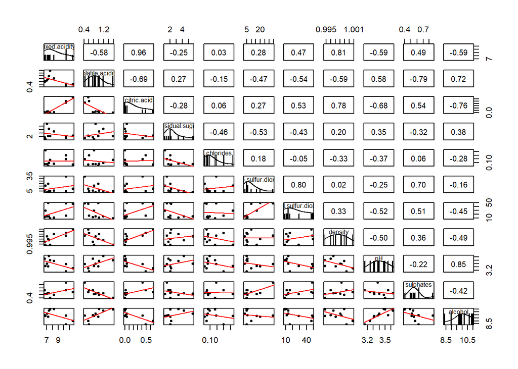

**For quality 8 wines:**

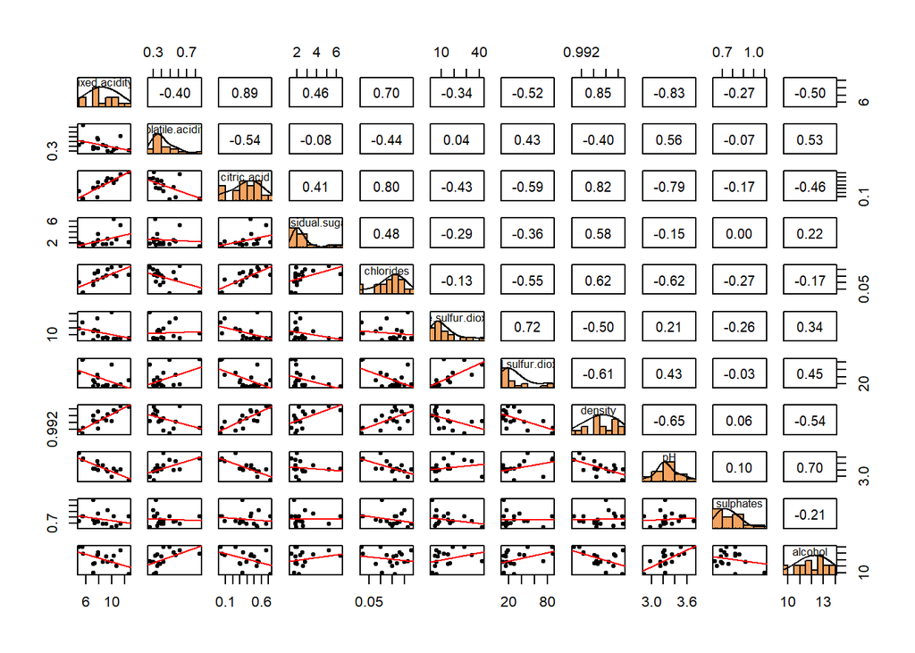

Same as the case of quality 3 wines, here there are a lot more variables who are correlated that when I used the entire data set, I’ll also select a Pearson’s correlation value of greater than 0.7 and less than -0.7. The correlated variables are:

- *Citric acid - Fixed acidity: 0.89*
- *Total sulfur dioxide - Free sulfur dioxide: 0.72*
- *Density - Citric acid: 0.82*
- *Density - Fixed acidity: 0.85*
- Chlorides - Fixed acidity: 0.70
- Chlorides - Citric acidity: 0.80
- pH - Citric acid: -0.79
- pH - Fixed acidity: - 0.83

The variables in *italics* are correlated in wines with quality 3 and 8.

Now I’ll create plots of some of the relationships for wines of only quality 3 and quality 8 scores.

#### For quality 8 wines:

**chlorides - citric acid: 0.80**

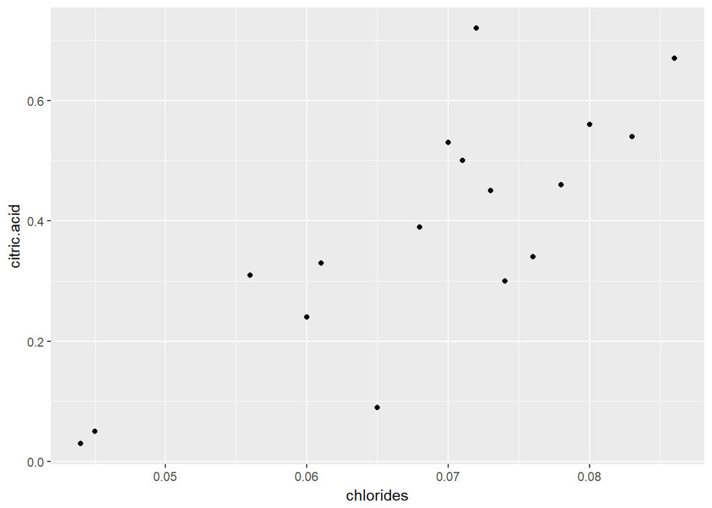

**pH - fixed acidity: -0.83**

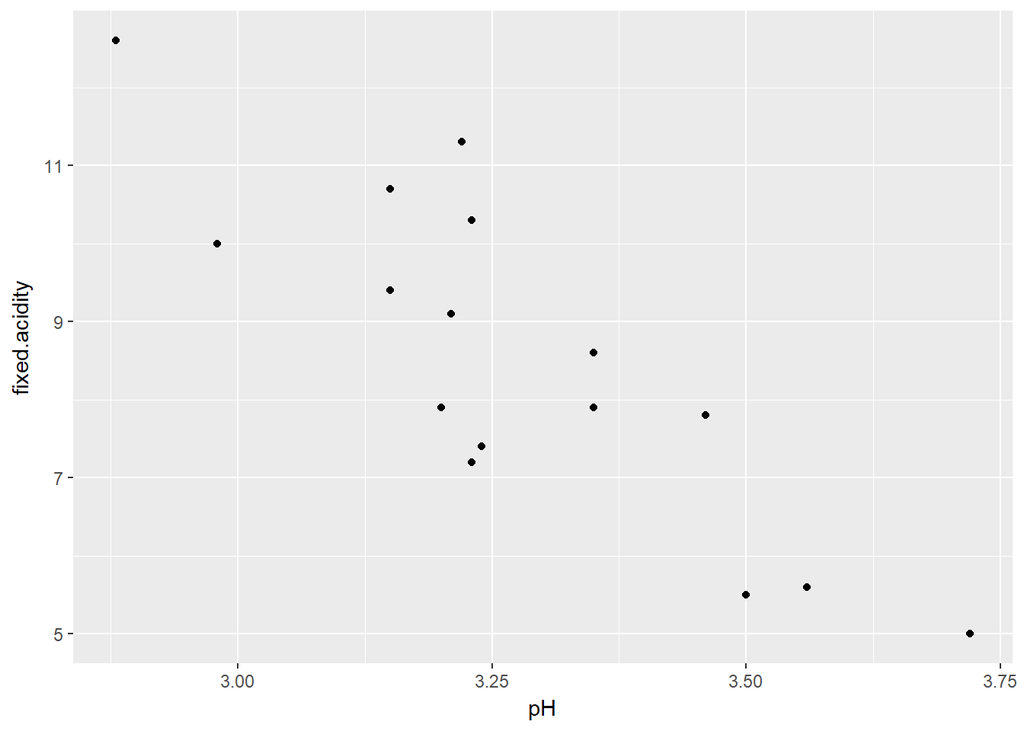

These plots present good relationship between the two pairs of variables: a positive linear relationship between citric acid and chlorides and a negative linear relationship between pH and fixed acidity.

#### For quality 3 wines:

**pH - alcohol: 0.85**

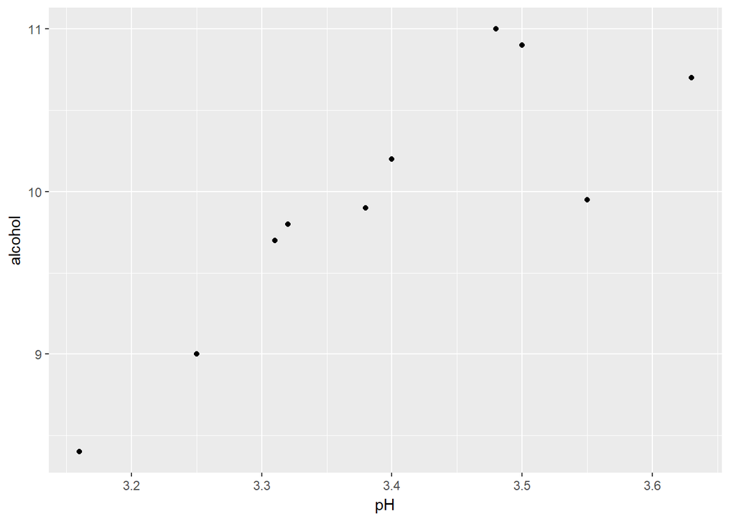

**Sulphates - volatile acidity: - 0.79**

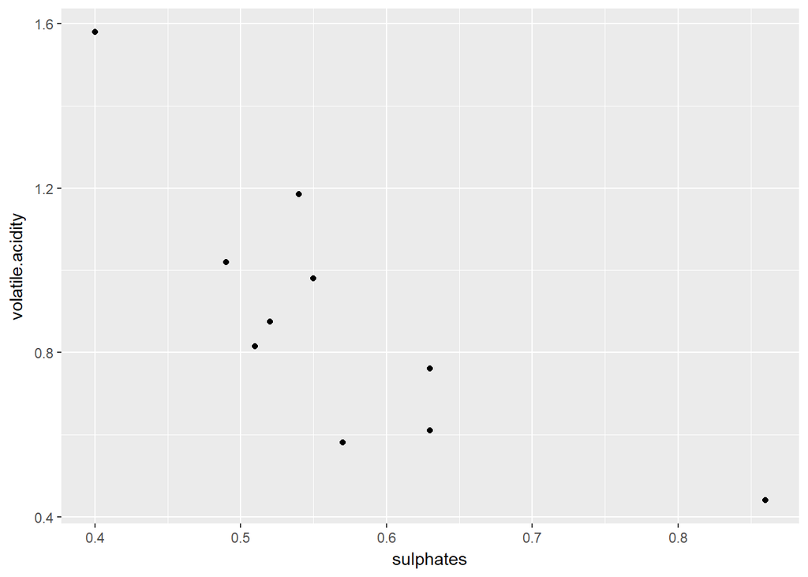

# Bivariate Analysis

### Talk about some of the relationships you observed in this part of the investigation. How did the feature(s) of interest vary with other features in the dataset?

I found that some variables seem to affect the quality of the wine. These variables are: volatile acidity, citric acid, chlorides, sulphates and alcohol.

### Did you observe any interesting relationships between the other features (not the main feature(s) of interest)?

Yes, I found two pairs of variables with a correlation of 0.67. These variables are: fixed acidity with density and free sulfur dioxide with total sulfur dioxide.

I also found interesting relationships when I studied wines of only quality 8 and 3. There are several pairs of variables that are correlated in both datasets, like:

- Density - fixed acidity
- Total sulfur dioxide - free sulfur dioxide
- Citric acid - fixed acidity
- Density - citric acid

From these variables, the fist two pairs are also related when we take into account the entire data set.

In the all of plots of the correlated variables in quality 3 and quality 8 wines, I could see a very clean distribution in all cases, this is mainly because there are very few observations in each case.

### What was the strongest relationship you found?

The strongest relationship I found is the correlation of fixed acidity and density and the volatile acidity with quality.

# Multivariate Plots Section

**Fixed acidity vs Density**

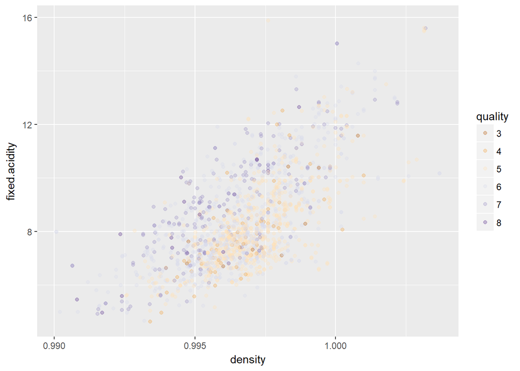

**Fixed acidity vs pH**

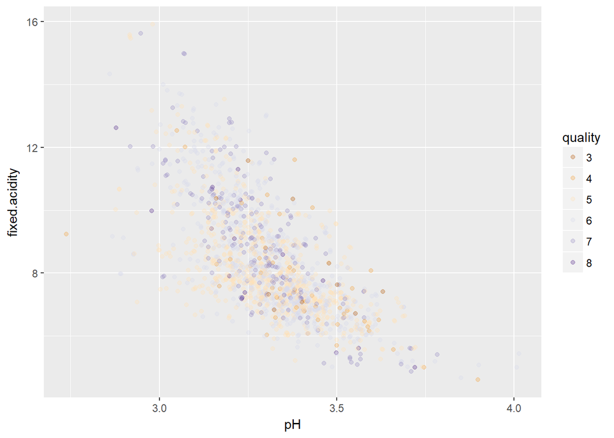

In the two plots above we can see that altough density - fixed acidity and pH - fixed acidity are correlated, when we color the points by the quality of wine there’s no apparent pattern.

**Citric acid vs pH**

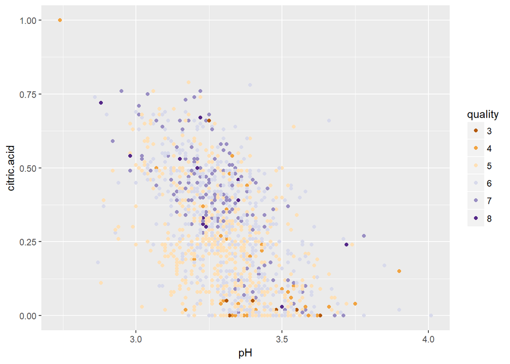

In this case, when we select to color the plot points with the quality variable, it is clear the distinction in good wines having higher citric acid levels.

**Total sulfur dioxide vs Free sulfur dioxide**

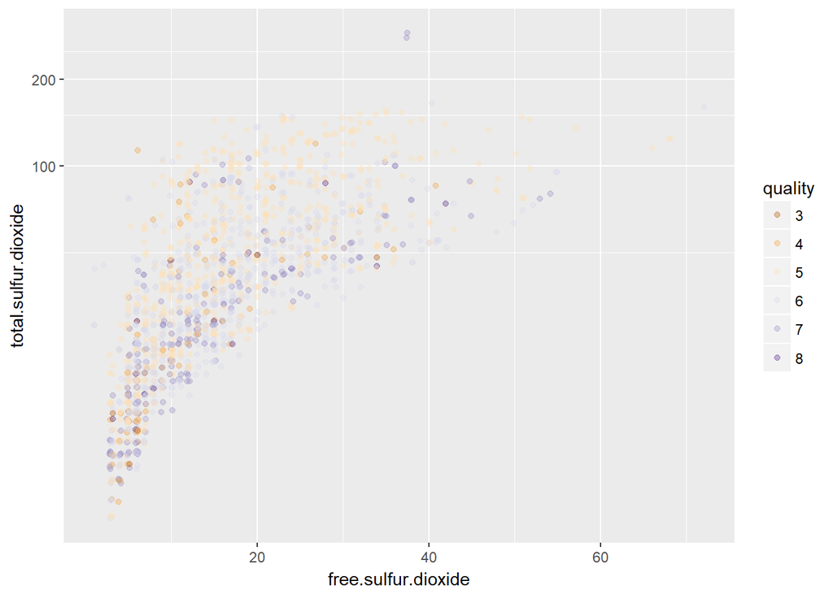

I made some transformations to this plot and although we can see a relationship between free sulfur dioxide and total sulfur dioxide, this relationship does not include the quality of the wine, as the quality points are disperse and there doesn’t seem to be a pattern between these two variables and wine quality

**Alcohol vs Density**

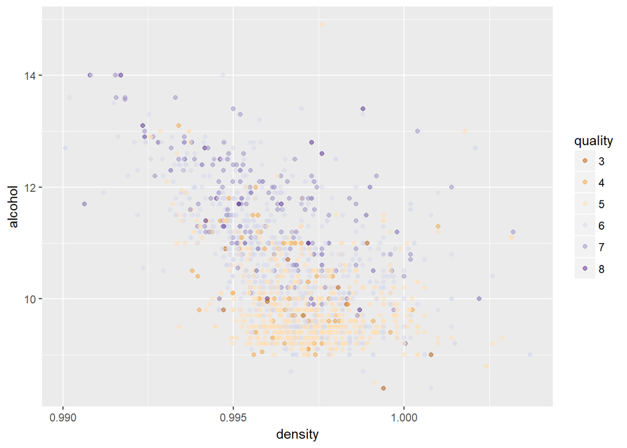

Here we can see that wines of better quality tend to have higher alcohol levels and lower density.

**Volatile acidity vs Citric acid**

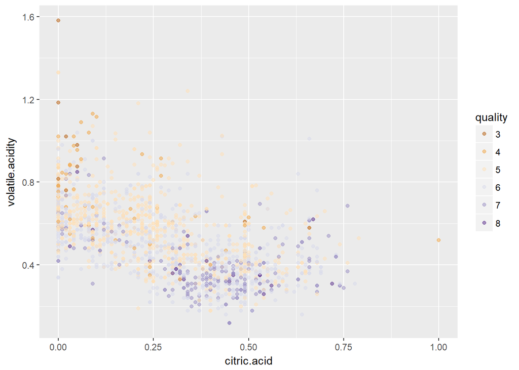

Although in this plot we cannot see a linear relationship between volatile acidity and citric acid, I believe that it is very representative as it indicates that wines with high citric acid values and low volatile acidity are of best quality than wines of low citric acid and high volatile acidity.

#### Now I’ll make some plots only compairing wines of quality 3 and 8

**Fixed acidity vs Citric acid**

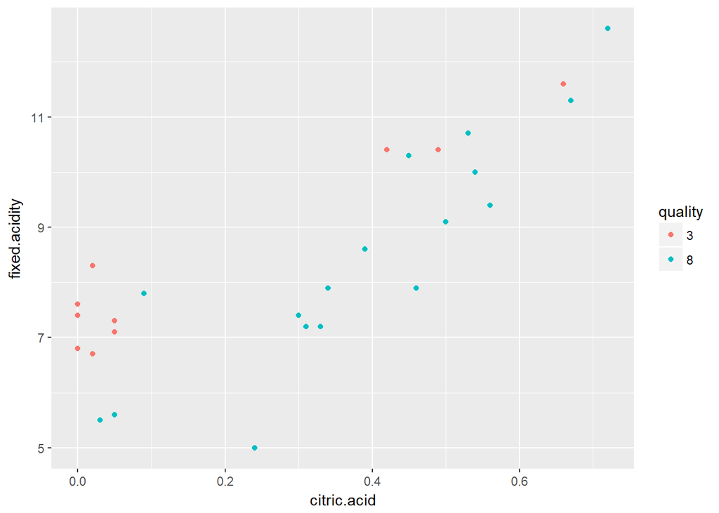

For quality 8 wines, there’s a clear positive linear relationship between citric acid and fixed acidity

**Total sulfur dioxide vs Free sulfur dioxide**

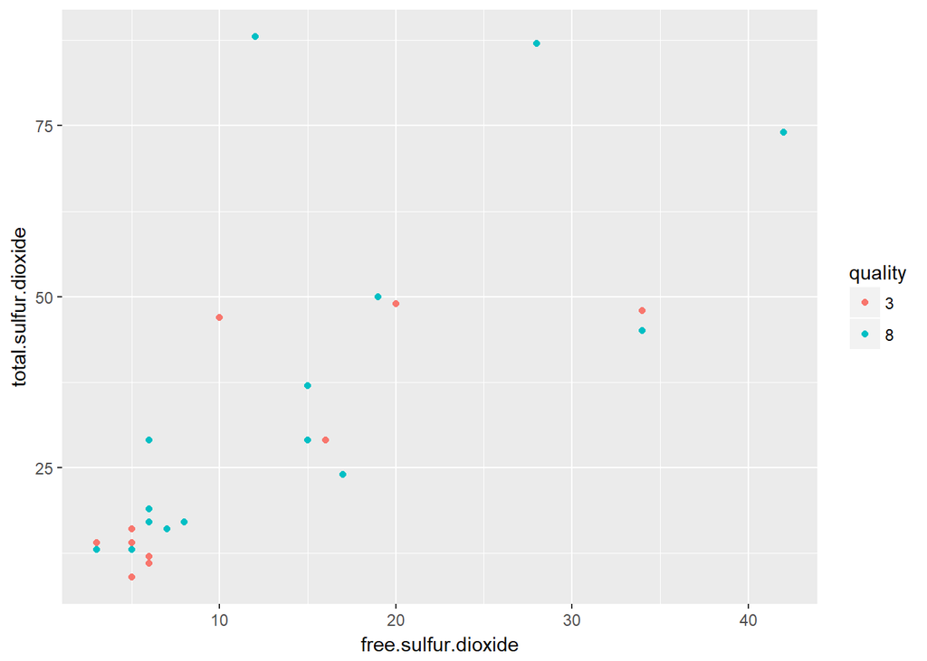

In this case, total sulfur and free sulfur seem to be related but there are some points who are disperse

**Citric acid vs Density**

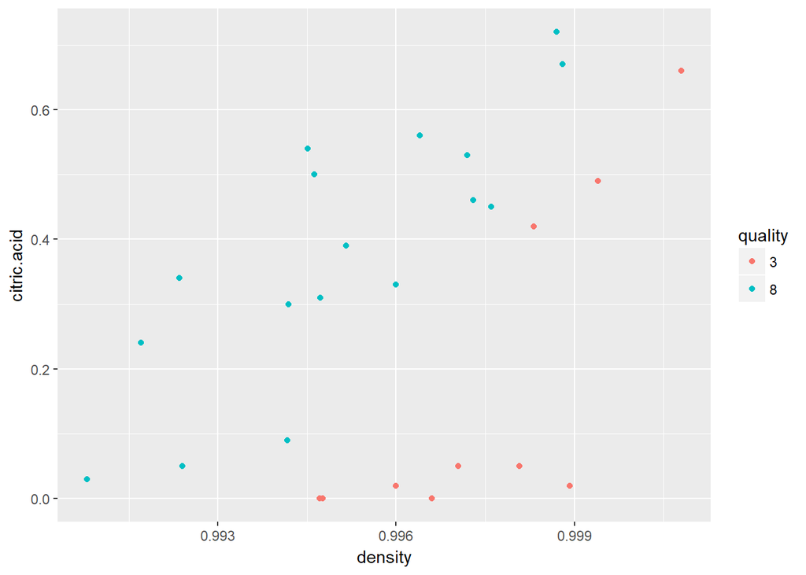

There are two tendencies here: one of wines with high levels of citric acid and another one of wines with lower levels of citric acid. In this second one, lay several quality 3 wines.

**Fixed acidity vs Density**

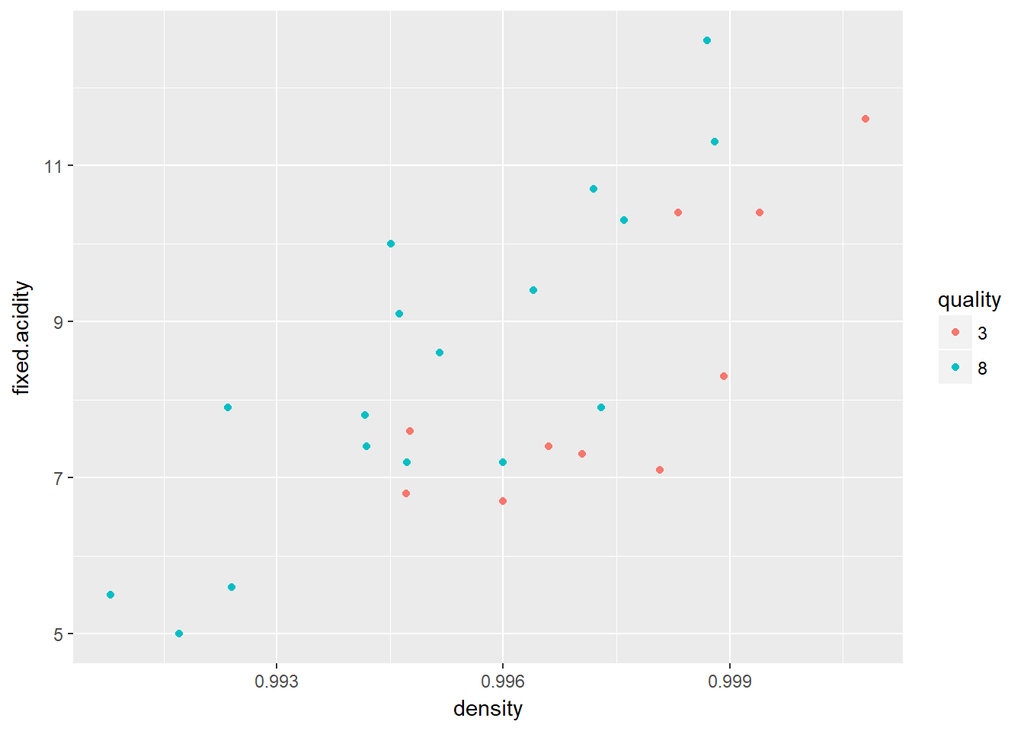

Density is clearly correlated with fixed acidity for quality 3 and 8 wines.

#### Linear model

Taking into account the variables that I found are the most influential in the quality of the wine, I’ll create a linear regression of wine quality

```
##
## Calls:
## m1: lm(formula = I(quality) ~ I(volatile.acidity), data = wine.num)
## m2: lm(formula = I(quality) ~ I(volatile.acidity) + citric.acid,
##     data = wine.num)
## m3: lm(formula = I(quality) ~ I(volatile.acidity) + citric.acid +
##     chlorides, data = wine.num)
## m4: lm(formula = I(quality) ~ I(volatile.acidity) + citric.acid +
##     chlorides + density, data = wine.num)
## m5: lm(formula = I(quality) ~ I(volatile.acidity) + citric.acid +
##     chlorides + density + sulphates, data = wine.num)
## m6: lm(formula = I(quality) ~ I(volatile.acidity) + citric.acid +
##     chlorides + density + sulphates + alcohol, data = wine.num)
## m7: lm(formula = I(quality) ~ I(volatile.acidity) + citric.acid +
##     chlorides + density + sulphates + alcohol + pH, data = wine.num)
##
## =========================================================================================================================
##                             m1            m2            m3            m4            m5            m6            m7
## -------------------------------------------------------------------------------------------------------------------------
##   (Intercept)              6.566***      6.529***      6.590***     94.753***     99.074***     -7.209        -5.885
##                           (0.058)       (0.089)       (0.089)      (10.722)      (10.402)      (11.982)      (11.930)
##   I(volatile.acidity)     -1.761***     -1.723***     -1.589***     -1.306***     -1.044***     -1.182***     -1.193***
##                           (0.104)       (0.125)       (0.127)       (0.129)       (0.127)       (0.120)       (0.119)
##   citric.acid                            0.063         0.232         0.676***      0.577***     -0.031        -0.269*
##                                         (0.115)       (0.119)       (0.128)       (0.125)       (0.123)       (0.136)
##   chlorides                                           -2.036***     -1.763***     -3.302***     -1.627***     -1.782***
##                                                       (0.410)       (0.403)       (0.419)       (0.407)       (0.407)
##   density                                                          -88.745***    -93.849***      9.946        10.281
##                                                                    (10.792)      (10.474)      (11.941)      (11.886)
##   sulphates                                                                        1.198***      0.857***      0.848***
##                                                                                   (0.118)       (0.112)       (0.112)
##   alcohol                                                                                        0.301***      0.321***
##                                                                                                 (0.020)       (0.020)
##   pH                                                                                                          -0.534***
##                                                                                                               (0.134)
## -------------------------------------------------------------------------------------------------------------------------
##   R-squared                0.153         0.153         0.166         0.200         0.248         0.343         0.350
##   adj. R-squared           0.152         0.152         0.164         0.198         0.246         0.341         0.347
##   sigma                    0.744         0.744         0.738         0.723         0.701         0.656         0.653
##   F                      287.444       143.812       105.506        99.340       105.227       138.762       122.332
##   p                        0.000         0.000         0.000         0.000         0.000         0.000         0.000
##   Log-likelihood       -1794.312     -1794.160     -1781.905     -1748.688     -1698.465     -1590.314     -1582.343
##   Deviance               883.198       883.030       869.598       834.209       783.418       684.297       677.509
##   AIC                   3594.624      3596.320      3573.811      3509.377      3410.931      3196.628      3182.686
##   BIC                   3610.756      3617.828      3600.696      3541.640      3448.571      3239.645      3231.080
##   N                     1599          1599          1599          1599          1599          1599          1599
## =========================================================================================================================
```

In this model, the r-squared value is 0.350.

# Multivariate Analysis

### Talk about some of the relationships you observed in this part of the investigation. Were there features that strengthened each other in terms of looking at your feature(s) of interest?

When I plotted alcohol vs density and volatile acidity vs citric acid and colored the points by the wine quality, I could see very clear trends between the pairs of variables and the quality of the wine. In the case of alcohol vs density, better quality wines tend to have high values of alcohol and lower density, while for volatile acidity vs citric acid, better quality wines have higher values of citric acid and lower volatile acidity.

### Were there any interesting or surprising interactions between features?

I found surprising the importance of density and pH and their correlation with other variables. When I studied these variables in the univariate analysis and when I made the box plots of compairing them with the different wine qualities, they did not seem to influence the quality but their relationship with other variables does seem to influence the wine quality.

### Did you create any models with your dataset? Discuss the strengths and limitations of your model.

I created a model to obtain the wine quality according to other variables and I got an r-squared value of 0.350, which is a little low, but I believe it’s a good value for this data, taking into account that wine quality is a subjective variable and a wine quality score can vary between each person depending on the individual tastes and preferences, so this model can give an roughly estimation of the quality of a wine.

# Final Plots and Summary

### Plot One

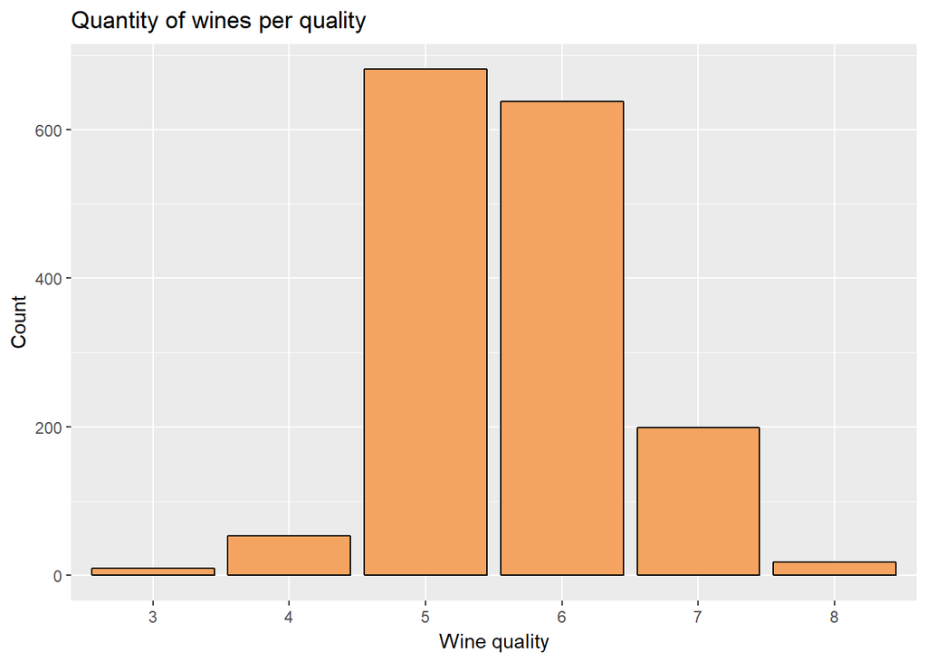

### Description One

In this plot we can see that most of the wines in the data set have quality 5 or 6. This variable is very subjective as this represents the median value of the qualification three or more people made. I find interesting that only 1.1 percent of the entire data set has quality 8 and that the score range was from 0 to 10 but in all the 1599 wines, the scores go from 3 to 8.

### Plot Two

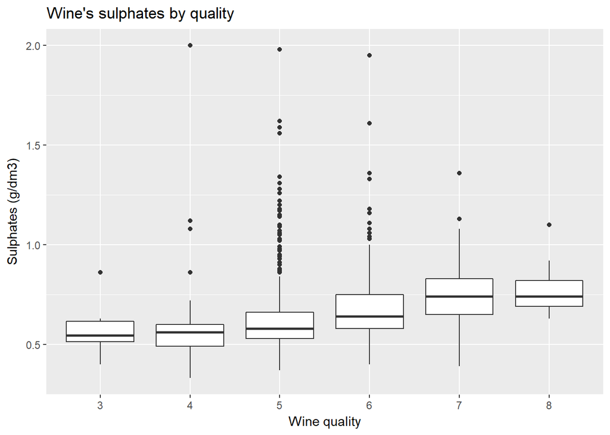

### Description Two

This plot describes how the amount of sulphates is related to the quality of the wine.

Sulphates are used to preserve wines because of its antioxidant (prevent wine’s oxidiation) and antiseptic (inhibiting the development of bacteria or fungi) properties(see refence 2), so it is common that “older” wines tend to have higher values of sulphates. And in this case, it seems that these wines are the ones of best quality.

### Plot Three

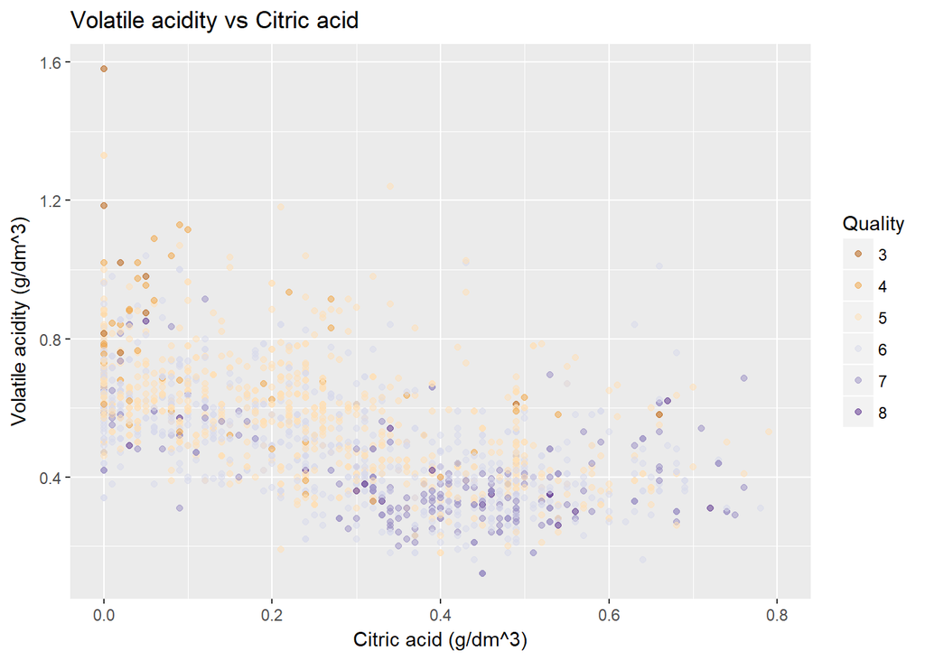

### Description Three

Here we can see the relationship of volatile acidity and citric acid in the quality of wines. Citric acid adds “freshness” and flavour to wines, while high levels of volatile acidity give a “vinegar” taste to wine.

It is noticeable in this plot that wines of better quality have high values of citric acid and low values of volatile acidity, while worst quality wines have low values of citric acid and high values of volatile acidity.

# Reflection

I worked with 1599 observations about red wine, with 11 chemical variables and one output: the quality of each wine. I studied the data following an order: first, making an univariate analysis to understand the ditribution of each variable, then a bivariate analysis to see relationships between pairs of variables and finally, a multivariate analysis.

Some of the struggles I went trough while making this analysis were working with several pairs of variables and analyzing which relationship influenced the most the quality of the wine. I also had to investigate about the chemical properties of red wines, to understand better the results I was obtaining and to be able to analyze them.

I believe the best finding in this analysis is the relationship between citric acid and volatile acidity with the quality of the wines.

I found surprising the relationship of density and pH with other variables. When I was starting to work with the data, I thought these variables would not be related to other variables or the quality of wine and I found several relationships that proved me wrong: one of the most importat relationship is the alcohol vs density with the quality of the wine. In the plot that takes those three variables into account, it is clear that wines of lower density and higher alcohol levels have better quality.

Some of the future work that can be done with the dataset is to add more observations that also include wines with quality values of 0, 1, 2, 9 and 10. It would also be interesting to study white wine data to see if the same relationships are found and to compare those findings with the ones of this analysis.

## References:

### Data set:

1. P. Cortez, A. Cerdeira, F. Almeida, T. Matos and J. Reis. Modeling wine preferences by data mining from physicochemical properties. In Decision Support Systems, Elsevier, 47(4):547-553. ISSN: 0167-9236.

Available at: [@Elsevier] http://dx.doi.org/10.1016/j.dss.2009.05.016 [Pre-press (pdf)] http://www3.dsi.uminho.pt/pcortez/winequality09.pdf [bib] http://www3.dsi.uminho.pt/pcortez/dss09.bib

### Consulted webpages:

2. http://socialvignerons.com/2017/03/02/sulphites-so2-in-wine-top-7-facts/ http://winefolly.com/tutorial/sulfites-in-wine/ http://www.smarte.org/smarte/dynamic/resource/sn-units-of-measure.xml.pdf https://www.statmethods.net/management/userfunctions.html https://stackoverflow.com/questions/14577412/how-to-convert-variable-object-name-into-string https://stackoverflow.com/questions/24576515/relative-frequencies-proportions-with-dplyr https://en.wikipedia.org/wiki/Web_colors http://blog.minitab.com/blog/adventures-in-statistics-2/regression-analysis-how-do-i-interpret-r-squared-and-assess-the-goodness-of-fit http://www.sthda.com/english/wiki/scatter-plot-matrices-r-base-graphs http://rmarkdown.rstudio.com/authoring_basics.html